# Forecasting Demo

Author

Josh Tyler

# Introduction

This is an example analysis report for the mpox forecasting competition. Here we outline an analysis workflow that starts at loading in the data and ends with the creation of the Estimates in the correct submission format.

# Organising The Data

In order to create a forecast, we must first load and clean the raw cases data. The historic data was filtered to include only months where all six WHO regions had case data provided and then a summary table was produced with each region having a total case number per month. We have also indexed the months for easier modelling and taken the log of the case numbers.

```r
library(tidyverse)
library(lubridate)
library(brms)
library(gt)
set.seed(1)

df<-read.csv(file = "data/aggregated_mpox_case_data.csv") |>
  as.data.frame() |>
  filter(month_start>"2022-06-01")|>
  group_by(who_region,month_start) |>
  summarise(cases=sum(cases)) |>
  as.data.frame()

df$cases<-log10(df$cases)

table(df$month_start)

df$month_start<-as.Date(df$month_start)

date_lookup<-data.frame(month_start=unique(df$month_start),
                        index=1:length(unique(df$month_start)))

who_regions<-unique(df$who_region)


df<-merge(x = df,y = date_lookup,by = "month_start") |>
  arrange(index,who_region)
df$m<-paste0(df$who_region,df$index)

end_index<-tail(unique(df$index),1)
```

# Plotting The Data

It is always important to check that the original data looks correct so we have replicated the figures from the WHO dashboard sowing case numbers per month for each of the 6 regions.

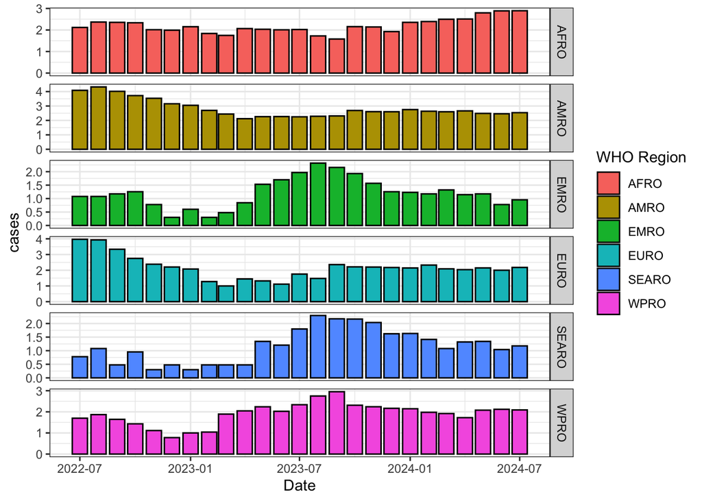

```r
ggplot(data = df)+
  geom_bar(aes(x=month_start,y=cases,fill = who_region),stat = "identity",col="black")+
  theme_bw()+
  facet_grid(who_region~.,scales = "free_y")+ scale_fill_discrete(name = "WHO Region")+
  xlab("Date")
```

# Creating a Forecast

In this example, we have chosen to use the `brms` package to fit a Bayesian Regression model, which is then extended to the remainder of 2024.

```r
fit1<-brm(cases ~ s(index,by=who_region,bs="bs"),data = df,
          family = gaussian(),cores = 8,chains = 8,iter = 5000)

newdf <- expand.grid(who_region=who_regions,index=1:(end_index+5))
newdf <- cbind(newdf, fitted(fit1, newdata = newdf)) |>
  arrange(index,who_region)
names(newdf) <- make.names(names(newdf))
newdf$m<-paste0(newdf$who_region,newdf$index)

tmp<-df[,c(3,5)]

newdf<-merge(x = newdf,y=tmp,by="m",all = T) |>
  arrange(index,who_region)
```

We can see that the fits are broadly in keeping with the historic data and that the prediction envelope expands rapidly as we move to the remaining months of 2024. This is due to our analyses being a “simple” regression rather than taking advantage of other datasets to help guide the predictions.

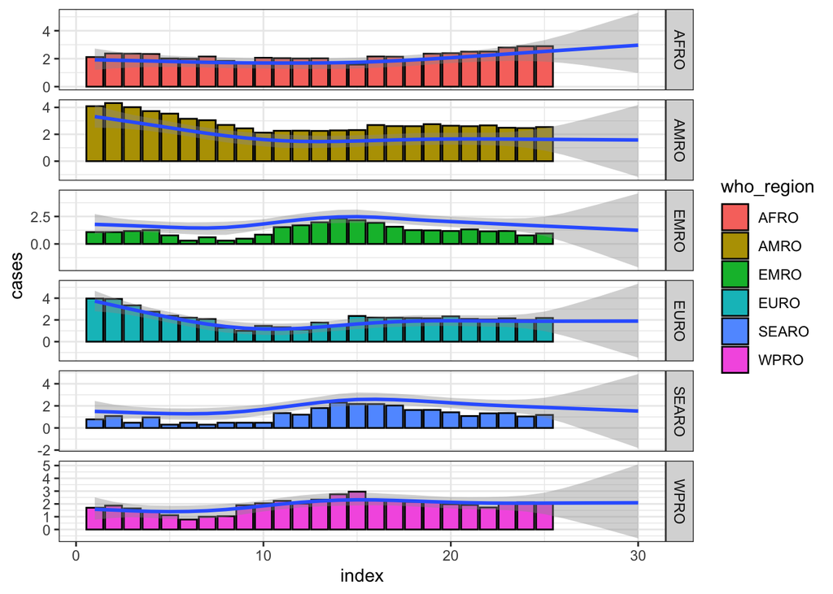

```r
ggplot(data = newdf,aes(x=index)) +
    geom_bar(aes(y=cases,fill = who_region),stat = "identity",col="black")+
    geom_smooth(aes(y=Estimate,ymin = Q2.5, ymax = Q97.5),stat = "identity")+
   facet_grid(who_region~.,scales = "free_y")+
  theme_bw()
```

# Creating the results table

The estimates of this competition must be given in a csv with 3 columns: WHO region, month_start and Estimate. Here we filter our estimates and convert the log(cases) to actual estimates and then save the results to be considered.

```r
results<-newdf |>
  filter(index>25) |>
  select(who_region,index,Estimate) |>
  mutate(Estimate=floor(10^Estimate))

results<- results |>
  mutate(month_start=as.Date(df$month_start[1]) %m+% months(results$index-1)) |>
  select(who_region,month_start,Estimate)

write.csv(results,"Mpox_forecast.csv",row.names = F)
```

```r
gt(results)
```

| who_region | month_start | Estimate |
| --- | --- | --- |
| AFRO | 2024-08-01 | 406 |
| AMRO | 2024-08-01 | 41 |
| EMRO | 2024-08-01 | 35 |
| EURO | 2024-08-01 | 76 |
| SEARO | 2024-08-01 | 62 |
| WPRO | 2024-08-01 | 116 |
| AFRO | 2024-09-01 | 498 |
| AMRO | 2024-09-01 | 40 |
| EMRO | 2024-09-01 | 29 |
| EURO | 2024-09-01 | 76 |
| SEARO | 2024-09-01 | 53 |
| WPRO | 2024-09-01 | 118 |
| AFRO | 2024-10-01 | 612 |
| AMRO | 2024-10-01 | 39 |
| EMRO | 2024-10-01 | 24 |
| EURO | 2024-10-01 | 77 |
| SEARO | 2024-10-01 | 46 |
| WPRO | 2024-10-01 | 119 |
| AFRO | 2024-11-01 | 752 |
| AMRO | 2024-11-01 | 38 |
| EMRO | 2024-11-01 | 20 |
| EURO | 2024-11-01 | 77 |
| SEARO | 2024-11-01 | 39 |
| WPRO | 2024-11-01 | 121 |
| AFRO | 2024-12-01 | 923 |
| AMRO | 2024-12-01 | 37 |
| EMRO | 2024-12-01 | 17 |
| EURO | 2024-12-01 | 77 |
| SEARO | 2024-12-01 | 33 |
| WPRO | 2024-12-01 | 122 |